# U.S. Medical Insurance Costs

#### by Pamela Mishaw

In this Python project, I use the pandas, matplotlib, and numpy libraries to examine a .csv file containing data pertaining to medical insurance costs in the United States to determine possible relationships between the insurance cost and demographics of the population surveyed.

## Data Importation and Identification of Variables

```python
# Package import
import numpy as np
import matplotlib.pyplot as plt
import seaborn as sns
import pandas as pd
from scipy.stats import pearsonr


# CSV is read and displayed
insurance = pd.read_csv("insurance.csv")
print(insurance.head())
```

```
   age     sex     bmi  children smoker     region      charges
0   19  female  27.900         0    yes  southwest  16884.92400
1   18    male  33.770         1     no  southeast   1725.55230
2   28    male  33.000         3     no  southeast   4449.46200
3   33    male  22.705         0     no  northwest  21984.47061
4   32    male  28.880         0     no  northwest   3866.85520
```

```python
insurance.info()
```

```
<class 'pandas.core.frame.DataFrame'>
RangeIndex: 1338 entries, 0 to 1337
Data columns (total 7 columns):
 #   Column    Non-Null Count  Dtype
---  ------    --------------  -----
 0   age       1338 non-null   int64
 1   sex       1338 non-null   object
 2   bmi       1338 non-null   float64
 3   children  1338 non-null   int64
 4   smoker    1338 non-null   object
 5   region    1338 non-null   object
 6   charges   1338 non-null   float64
dtypes: float64(2), int64(2), object(3)
memory usage: 73.3+ KB
```

After reading the .csv file into a dataframe, I am able to display the column titles and first few rows of the dataset. The "charges" column is assumed to be the annual insurance cost for the individual.

```python
insurance.describe()
```

|  | age | bmi | children | charges |
| --- | --- | --- | --- | --- |
| count | 1338.000000 | 1338.000000 | 1338.000000 | 1338.000000 |
| mean | 39.207025 | 30.663397 | 1.094918 | 13270.422265 |
| std | 14.049960 | 6.098187 | 1.205493 | 12110.011237 |
| min | 18.000000 | 15.960000 | 0.000000 | 1121.873900 |
| 25% | 27.000000 | 26.296250 | 0.000000 | 4740.287150 |
| 50% | 39.000000 | 30.400000 | 1.000000 | 9382.033000 |
| 75% | 51.000000 | 34.693750 | 2.000000 | 16639.912515 |
| max | 64.000000 | 53.130000 | 5.000000 | 63770.428010 |

```python
# The dataset is checked for null values
insurance.isnull().values.any()
```

```
False
```

No null values were found in the dataframe and the output from the .describe() function did not suggest any missing data, either. Thus it appears that I do not have to take missing values into account in my analysis.

An aspect that piqued my curiosity is the relationship between region and insurance cost.

## Data Visualization

```python
# Display total medical insurance costs by U.S. region
regional_cost = insurance.groupby("region").charges.sum().reset_index()

print(regional_cost)
```

```
      region       charges
0  northeast  4.343669e+06
1  northwest  4.035712e+06
2  southeast  5.363690e+06
3  southwest  4.012755e+06
```

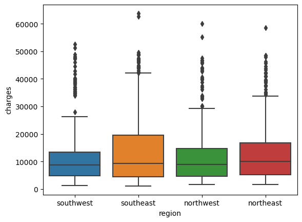

```python
sns.boxplot(data = insurance, x = "region", y = "charges")
```

The median value of the medical insurance costs for each region are very similar and there is significant overlap in the IQRs. It appears that, when comparing the IQRs, the cost data coming from the southeast region has a greater percentage of individuals who pay a higher amount for medical insurance. The southeast region also has a significantly higher maximum medical insurance cost compared to the other regions.

Notably, the "charges" variable displays a greate number of high-valued outliers for each region. The Southeast shows the highest outlier, as well.

My next step is to investigate the other variables for each region to determine if these may be related to the difference in costs.

```python
print((insurance.region.value_counts()) / len(insurance))
```

```
region
southeast    0.272048
southwest    0.242900
northwest    0.242900
northeast    0.242152
Name: count, dtype: float64
```

The Southeast represents a slightly higher percentage of the dataset which may be a contributor to the greater IQR and maximum values for this group-- a greater sample size allows for a greater chance of introducing a value that increases the range.

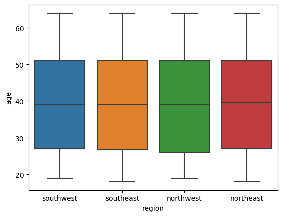

```python
sns.boxplot(data = insurance, x = "region", y = "age")
```

The median age, IQR, and range of the regions are almost identical so this does not appear to be an influence.

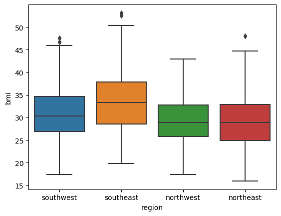

```python
sns.boxplot(data = insurance, x = "region", y = "bmi")
```

The median value of BMI for the Southeast is significantly higher than those of the other regions, a factor that is a known contributor to higher healthcare costs.

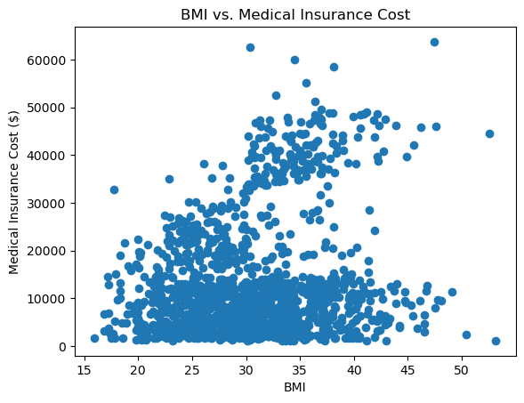

```python
plt.scatter(x = insurance.bmi, y = insurance.charges)

plt.title("BMI vs. Medical Insurance Cost")
plt.xlabel("BMI")
plt.ylabel("Medical Insurance Cost ($)")
```

```python
corr_bmi_cost, p = pearsonr(insurance.bmi, insurance.charges)
print(corr_bmi_cost)
```

```
0.19834096883362912
```

The scatterplot and Pearson correlation value suggest a weak positive correlation between bmi and medical insurance cost for the dataset as a whole.

```python
# Find number/proportion of smokers in each region.
smoker_region_cross = pd.crosstab(index = insurance.region, columns = insurance.smoker)
print(smoker_region_cross)
```

```
smoker      no  yes
region
northeast  257   67
northwest  267   58
southeast  273   91
southwest  267   58
```

```python
smoker_prop = smoker_region_cross / len(insurance)
print(smoker_prop)
```

```
smoker           no       yes
region
northeast  0.192078  0.050075
northwest  0.199552  0.043348
southeast  0.204036  0.068012
southwest  0.199552  0.043348
```

The Southeast region also had a greater number and percentage of respondents who declared themselves as smokers, another variable which adds to the healthcare cost burden of a population.

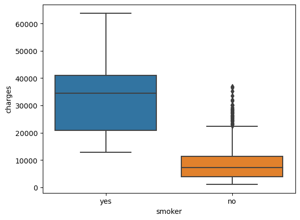

```python
sns.boxplot(data = insurance, x = "smoker", y = "charges")
```

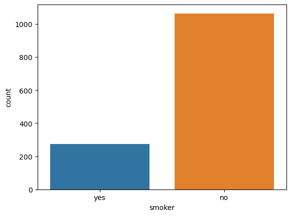

```python
sns.countplot(x = "smoker", data = insurance)
```

This boxplot supports the theory of the greater number of smokers in the Southeast group relating to the higher medical insurance costs in the area-- the smoker group, though a small portion of the dataset overall (shown in the bar graph), has a much greater median medical insurance cost.

I am also interested in examining the relationship between sex and medical insurance cost.

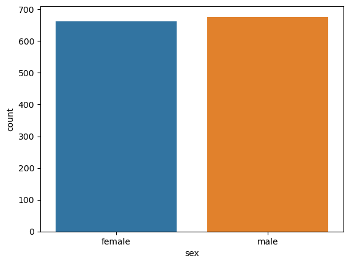

```python
sns.countplot(x = "sex", data = insurance)
```

```python
sex_region_cross = pd.crosstab(index = insurance.region, columns = insurance.sex)
print(sex_region_cross)
```

```
sex        female  male
region
northeast     161   163
northwest     164   161
southeast     175   189
southwest     162   163
```

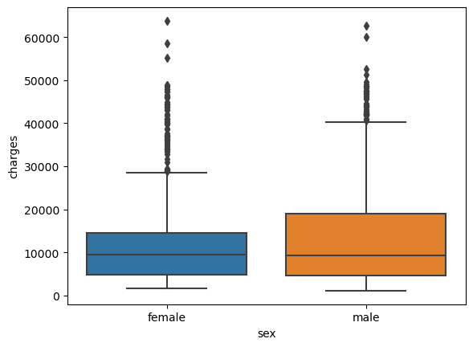

```python
sns.boxplot(data = insurance, x = "sex", y = "charges")
```

The overall dataset and each geographic region have an almost equal split between the groups "male" and "female," as a good study should be. The median medical insurance cost for each of the sexes are very similar but the male part of the study group has a greater spread of values in the middle 50% of documented medical insurance costs and so the male portion of the dataset has a greater number of people with higher medical insurace costs.

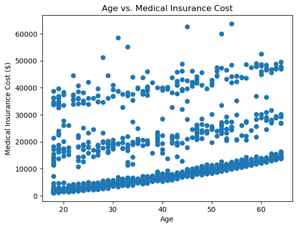

```python
plt.scatter(x = insurance.age, y = insurance.charges)

plt.title("Age vs. Medical Insurance Cost")
plt.xlabel("Age")
plt.ylabel("Medical Insurance Cost ($)")
```

```python
corr_age_cost, p = pearsonr(insurance.age, insurance.charges)
print(corr_age_cost)
```

```
0.2990081933306478
```

There is a weak positive correlation between age and medical insurance costs.

## Conclusion

My exploration of the data revealed a greater overall medical insurance cost for those surveyed in the Southeast Region compared to other regions of the United States. This region also showed the greatest median BMI and number/proportion of smokers. The idea that these factors may be contributors to the higher medical insurance costs was supported by weak but positive correlation between BMI and health insurance cost as well as the greater median health insurance cost for the smoker group.

The results suggest that greater efforts should be made in the Southeast to combat the obesity rates as compared to the other regions as well as devote more resources to reducing the number of smokers in order to relieve the region of its burden of healthcare costs.